# Praca domowa 3

Martyna Sadowska

## Analizowany wykres

Wykresy są analizą głosów oddanych w listopadowych wyborach powrzechnych w hrabstwie King, w Waszyngtonie. Wykresy są publikowane na stronie: https://kingcounty.gov/en/dept/elections/results/ballot-return-statistics/2024/november-general. Są one na bieżąco aktualizowane, tak samo jak dane, z których są pobierane informacje o oddanych głosach: https://www.sos.wa.gov/elections/data-research/election-data-and-maps/ballot-status-reports.

Zdjęcie, które znalazłam: https://www.reddit.com/r/dataisugly/comments/1gc9cr8/im_confused_by_the_pie_chart_%D5%AE_o/#lightbox zostało wykonane 25.10.2024 r.

[figure not shown]

```r
bad_ballot_chart <- load.image("ballot_return_statistics.jpeg")
plot(bad_ballot_chart, axes = FALSE)
```

**Komentarz:**

Żaden z tych trzech wykresów nie jest wykonany idealnie, ale w mojej analizie skupię się na wykresie kołowym.

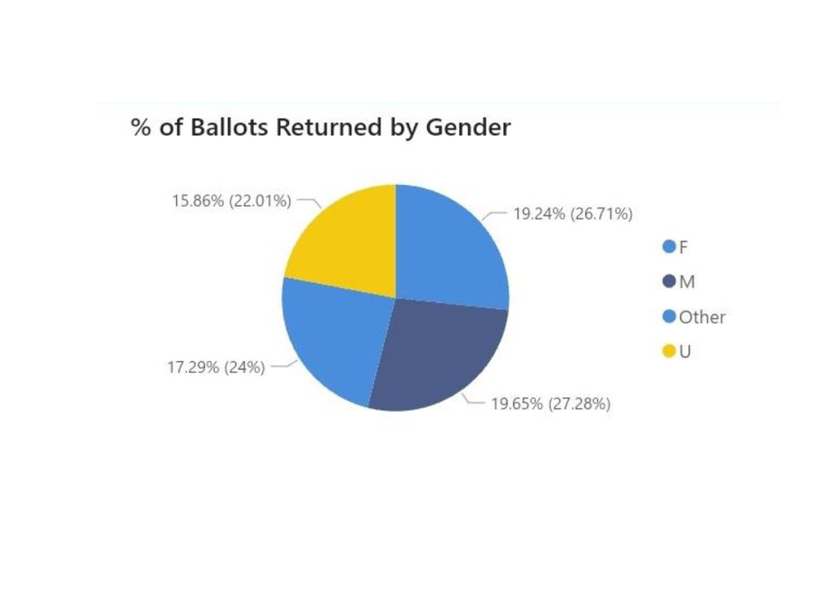

```r
bad_ballot_pie_chart <- load.image("ballot_return_statistics_pie_chart.jpeg")
plot(bad_ballot_pie_chart, axes = FALSE)
```

**Co wymaga poprawy:**

Pierwszym problemem tego wykresu jest to, że jest wykresem kołowym, ale to nie wszystko, co sprawia, że jest on bardzo nieczytelny. Płeć jest podzielona na cztery kategorie: kobieta, mężczyzna, inna i nieznana, co nie jest tak oczywiste z legendy. Nie wiadomo też, w jaki sposób występuje rozróżnienie między inną a nieznaną, skoro w badanych danych jest to jedna kategoria. Kolor dla “F” i “Other” jest tak podobny, że nie da się stwierdzić, która część koła odnosi się do której kategorii. Najbardziej niezrozumiałą częścią wykresu są podwójne procentowe podpisy. Dopiero po dłuższej analizie można zrozumieć, że pierwsza etykieta dotyczy procentu osób danej płci, które oddały głos. Natomiast czym są procenty w nawiasach? Tylko one sumują się do 100%. Okazuje się, że powstały one tylko po to, aby stworzyć wykres kołowy - są to “znormalizowane” procenty z pierwszej etykiety, tak aby tworzyły pełne 100%. (Na przykład 15.86 stanowi 22.01% z 15.86+19.24+19.65+17.29)

## Zmieniony wykres

**Komentarz:**

Ponieważ oba źródła aktualizują cały czas swoje dane, to mimo przefiltrowania danych o głosach, liczby na moim wykresie nie są dokładnie takie same, jak na wykresie źródłowym.

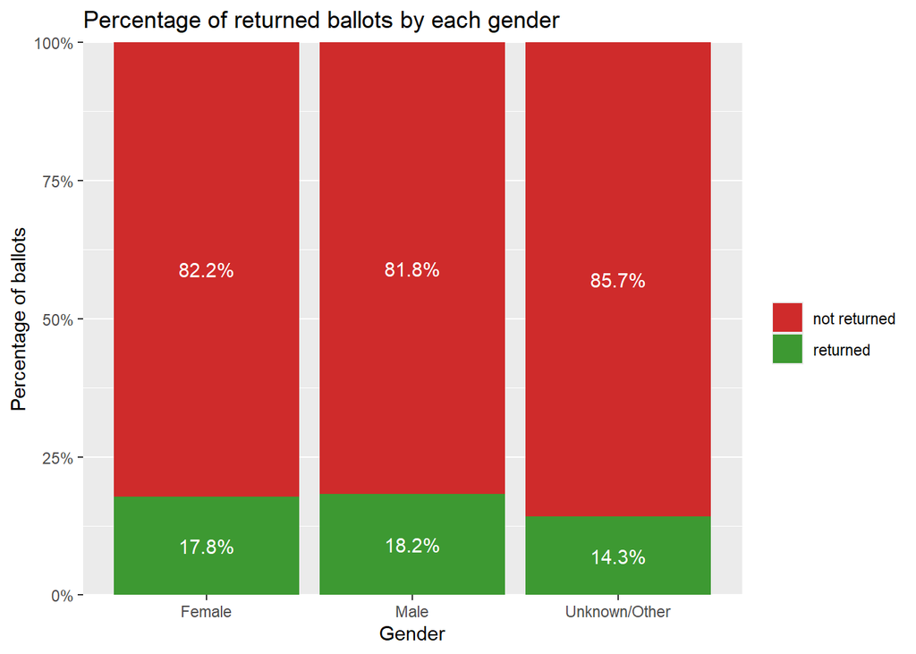

```r
df_ballot_status <- suppressWarnings(read_csv("Ballot Status Report.csv"))
df_king_age <- suppressWarnings(read_excel("Voter Demographics Tables.xlsx",
                          sheet = "County and Age Group") %>%
  filter(County == "King"))
df_king_gender <- suppressWarnings(read_excel("Voter Demographics Tables.xlsx",
                          sheet = "County and Gender") %>%
  filter(County == "King"))

df_king <- df_ballot_status %>% filter(County == "King")
df_ballot_range <-  df_king %>%
  mutate(`Received Date` =
           as.POSIXct(`Received Date`, format = "%m/%d/%Y %I:%M:%S %p")) %>%
  filter(`Received Date` < as.POSIXct("2024-10-24 17:00:00"))

df_ballot_gender <- df_ballot_range %>% mutate(Gender = case_when(
    Gender == "M" ~ "Male",
    Gender == "F" ~ "Female",
    TRUE ~ "Unknown/Other"
  )) %>%  group_by(Gender) %>%
  summarise(Count = n()) %>%
  mutate(Percent = Count / sum(Count) * 100)

voters_gender <- df_king_gender %>% pivot_longer(!County, names_to = "Gender", values_to = "Voters")
df_plot_1 <- df_ballot_gender %>% right_join(voters_gender, by = "Gender") %>%
  filter(Gender != "Total") %>% select(-County) %>%
  mutate(Ballots_Returned = Count / Voters * 100, Ballots_Not_Returned = 100 - Ballots_Returned)

plot_1 <- df_plot_1 %>% pivot_longer(cols = c("Ballots_Returned", "Ballots_Not_Returned"),
                          names_to = "Ballots", values_to = "Values") %>%
  ggplot(aes(x = Gender, y = Values, fill = Ballots)) +
  geom_bar(stat = "identity", position = "stack") +
  scale_y_continuous(labels = percent_format(scale = 1), expand = c(0, 0)) +
  geom_text(aes(label = paste0(round(Values, 1), "%")),
            position = position_stack(vjust = 0.5),
            color = "white") +
  labs(x = "Gender", y = "Percentage of ballots", fill = "",
       title = "Percentage of returned ballots by each gender") +
  scale_fill_manual(values = c("Ballots_Returned" = "#3d9932",
                               "Ballots_Not_Returned" = "#cf2b2b"),
                    labels = c("Ballots_Returned" = "returned",
                               "Ballots_Not_Returned" = "not returned"))
plot_1
```

**Co poprawiłam:**

Przeniosłam dane na wykres słupkowy. Od razu dużo bardziej widoczny jest procent oddanych głosów przez daną płeć. Pozbyłam się mylących procentów, które tworzyły wykres kołowy. Przez zmianę typu wykresu, nie potrzebowałam oddzielnych kolorów dla płci, ale dokładniej je opisałam. Płci nieznana i inna stały się jednym słupkiem, bo tylko takie dane są dostępne. Kolorami oznaczyłam oddane i nieoddane głosy, co dodatkowo poprawia czytelność.